# Importing, processing, and exploring Visium data

Data Lab for ALSF

2026

## Objectives

- Read Visium data into R
- Filter to spots overlapping tissue
- Calculate quality control measures on spatial transcriptomic data
- Remove likely low-quality spots with `SpotSweeper()`
- Normalize gene expression data
- Visualize spatial transcriptomic data

## Introduction

In this notebook, we’ll learn some basics of import, processing, and visualization of a Visium data set.

We will be using an anaplastic Wilms Tumor sample from the the [Single-cell Pediatric Cancer Atlas](https://scpca.alexslemonade.org/projects/SCPCP000006). This sample was processed using first-generation Visium technology, and it was quantified with [`Space Ranger 1.3.1` from 10x Genomics](https://www.10xgenomics.com/support/software/space-ranger/latest). We will use the outputs from Space Ranger as our starting point for analysis in this notebook.

## Set up

To begin, we’ll load `SpatialExperiment`, the core package for spatial transcriptomic objects in Bioconductor, as well as some packages for plotting.

```r
# The main class we use for spatial transcriptomic data
library(SpatialExperiment)
# To support plotting
library(ggplot2)
library(patchwork)

# Set ggplot2 theme
theme_set(theme_bw())
```

### Directories and files

Next we’ll define input paths and files that we’ll use in this notebook.

There are a variety of files that you will often see as part of the standard Space Ranger output. The specific files present will depend on which specific spatial technology you are using, but they are all described in detail in [10x Genomics documentation](https://www.10xgenomics.com/support/software/space-ranger/latest/analysis/outputs/output-overview).

We’ve placed the core outputs you’ll need for reading this first-generation Visium data into R in the directory `data/wilms-tumor/SCPCS000190`, organized into folders as Space Ranger returns them. We’ll define that input path, along with other inputs we’ll need, here.

```r
# define sample id we'll be analyzing
sample_id <- "SCPCS000190"

# main data directory for this sample
data_dir <- file.path("data/wilms-tumor", sample_id)

# directory with spaceranger output
spaceranger_dir <- file.path(data_dir, "spaceranger")

# reference data directory
ref_dir <- file.path("data/reference")

# Path to mitochondrial genes table
mito_file <- file.path(ref_dir, "hs_mitochondrial_genes.tsv")
```

And now, we’ll define the output paths and files we’ll use for exporting.

```r
# Directory and file to save output
normalized_dir <- file.path(data_dir, "normalized")

# create the directory if it does not exist
fs::dir_create(normalized_dir)

# output RDS file for normalized Spatial Experiment (SPE) object
# we'll use the existing sample_id variable to write the file name
output_spe_file <- file.path(
  normalized_dir,
  glue::glue("{sample_id}_normalized.rds")
)
```

## Reading Space Ranger data

Space Ranger output includes count data, spatial information, and images. The count data is generally provided in two main formats, just as Cell Ranger would provide them for single-cell data:

1. A folder with a feature list, a barcode list, and a sparse matrix in [“Matrix Exchange” format](https://math.nist.gov/MatrixMarket/formats.html), and
2. An `HDF5` formatted file containing all this information.

Because the data we’re working with comes from the [ScPCA Portal](https://scpca.alexslemonade.org/), which only provides the folder format, that’s what we’ll read in here.

Space Ranger also outputs both filtered and raw matrices; today we will start with the raw matrix and perform all of our own filtering.

Before importing the data, let’s go ahead and look what files we have:

```r
dir(spaceranger_dir)
```

```
[1] "filtered_feature_bc_matrix"
[2] "raw_feature_bc_matrix"
[3] "SCPCL000429_spaceranger-summary.html"
[4] "spatial"
```

```
filtered_feature_bc_matrix
raw_feature_bc_matrix
SCPCL000429_spaceranger-summary.html
spatial
```

As described, the `raw_feature_bc_matrix` and `filtered_feature_bc_matrix` directories are analogous to what we might get from Cell Ranger for single-cell data. However, unlike single-cell data where these barcodes correspond to droplets (some of which are actual cells), the barcodes in Visium data correspond to *spots*. Here, each spot corresponds to a 55 µm diameter area on the slide that contains roughly 1-10 cells, depending on the tissue type being analyzed. In this particular Visium data set, spots are laid out on a 6.5x6.5 mm slide (although other experiments may be 11x11 mm for larger tissue sections).

While the `raw_feature_bc_matrix` contains data for all possible spots, the `filtered_feature_bc_matrix` contains data only for spots that overlap tissue.

Parallel to these directories is the `spatial` directory which contains files that provide the full spatial context to go along with the feature-by-barcode count matrices. Let’s take a closer look at what’s in the `spatial` directory:

```r
dir(
  file.path(spaceranger_dir, "spatial")
)
```

```
[1] "aligned_fiducials.jpg"     "detected_tissue_image.jpg"
[3] "scalefactors_json.json"    "tissue_hires_image.png"
[5] "tissue_lowres_image.png"   "tissue_positions_list.csv"
```

```
aligned_fiducials.jpg
detected_tissue_image.jpg
scalefactors_json.json
tissue_hires_image.png
tissue_lowres_image.png
tissue_positions_list.csv
```

We see several different files here, which we’ll go ahead and look at directly by clicking on them in the Files Pane. Below are brief descriptions of each file we see here, and others that would be represented by more recent Visium technologies.

##### `aligned_fiducials.jpg`

This image file shows the provided tissue image with a border of the *fiducials*, which are small dots surrounding the slide capture area. Space Ranger uses fiducials to anchor the quantified gene expression onto the tissue image itself, and this image can help you see how successful that *fiducial alignment* was. If something looks really off in this image (e.g., it looks distorted, or some fiducials are missing), that’s a sign you may need to manually adjust the alignment and run Space Ranger again.

##### `detected_tissue_image.jpg`

Part of Space Ranger’s algorithm involves identifying which spots overlay tissue and which do not. This image file shows the Visium grid of spots overlaid on the tissue, where spots that overlay tissue are shaded in. It’s important to filter out spots that do not overlay tissue before proceeding with analysis. This is because those spots will have 0 gene expression, but that doesn’t mean that those genes weren’t actually expressed elsewhere. Those values of 0 mean that there was simply nothing to sequence, and we don’t want them to contribute noise.

##### `tissue_hires_image.png` and `tissue_lowres_image.png`

These are two different versions of the provided tissue image that have each been down-scaled for size to, respectively, ~2000 pixels and ~600 pixels.

##### `tissue_positions_list.csv`

This CSV file provides the tissue coordinates for each spot, indexed by its barcode.

##### `scalefactors_json.json`

This JSON file stores the specific scaling factors used to downsize the provided tissue image to the provided image resolutions.

##### Other files you might see

In other Visium datasets, you may see more files in the `spatial/` directory than you see here. In particular, this data was prepared with the first-generation Visium technology, in which tissue was manually placed directly onto a Visium capture slide. Most current Visium experiments use an upgraded technology called CytAssist, an instrument that assists in transferring tissue from a standard slide to the Visium capture slide and dramatically improves FFPE tissue processing.

In Visium CytAssist datasets, there will be two additional image files you should be aware of:

- `cytassist_image.tif`: This is the image captured by the CytAssist instrument itself and is the primary image file that Space Ranger uses when processing CytAssist data
- `aligned_tissue_image.jpg`: If you provided a microscope image, such as an H&E or fluorescence image, along with the CytAssist image to a CytAssist run, Space Ranger will also return the microscope image aligned to the CytAssist image’s coordinates

There may also be additional files, depending on which version of Space Ranger was used, but these are the core files to be aware of for first-generation Visium data and for CytAssist data.

### Import with `VisiumIO`

We’ll begin by importing the raw counts and spatial information into a `SpatialExperiment` (SPE) object. This object is a derived version of the `SingleCellExperiment` (SCE) object that contains a couple more slots that augment the object with spatial information. This means there are some functions we’ll use to interact with the object that you might recognize from your adventures with SCE objects, but there will also be some new functions that are just used for SPE objects.

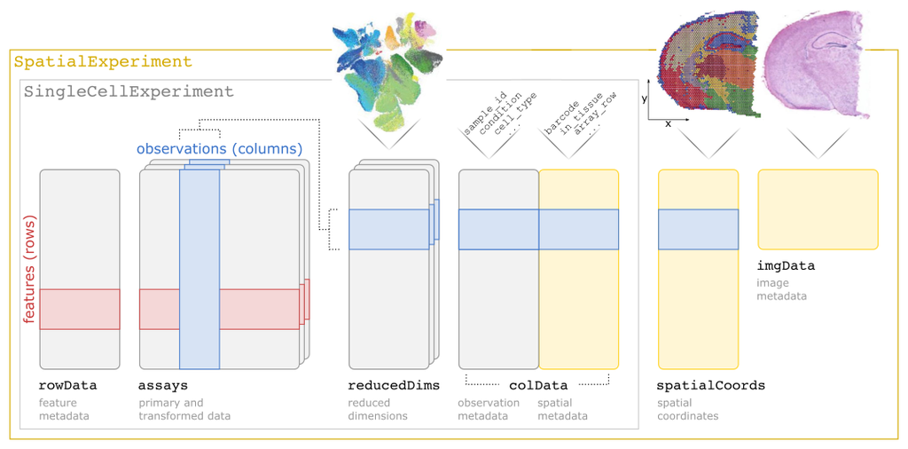

For more information on `SpatialExperiment` objects, as well as many other topics related to this course, we highly recommend the e-book [*Orchestrating Spatial Transcriptomics with Bioconductor* (OSTA)](http://bioconductor.org/books/release/OSTA/).

To import Visium data with the `VisiumIO` package, we’ll need to specify three items (the rest should be automatically detected):

- The path to the Space Ranger count output, which in this case is the `raw_feature_bc_matrix` folder
- The path to the Space Ranger spatial output, which corresponds to the `spatial` directory
- Which image(s) should be imported into the object

By default, this function will try to import several image types, including the CytAssist image which we don’t have here. So, in this case we’ll specify to import only the `lowres` version of the image.

```r
# path to quantified RNA 10X output
rna_dir <- file.path(spaceranger_dir, "raw_feature_bc_matrix")

# path to spatial 10X output
spatial_dir <- file.path(spaceranger_dir, "spatial")

# import to an object called spe
spe <- VisiumIO::import(
  VisiumIO::TENxVisium(
    # path that contains the sequencing data
    resources = rna_dir,
    # path that contains the spatial data
    spatialResource = spatial_dir,
    # which image(s) to import - we'll use lowres to save some memory/space
    images = "lowres"
  )
)
```

Let’s have a look:

```r
# print the spe
spe
```

```
class: SpatialExperiment
dim: 60664 4992
metadata(2): resources spatialList
assays(1): counts
rownames(60664): ENSG00000284662 ENSG00000186827 ... ENSG00000277475
  ENSG00000275405
rowData names(3): ID Symbol Type
colnames(4992): AAACAACGAATAGTTC-1 AAACAAGTATCTCCCA-1 ...
  TTGTTTGTATTACACG-1 TTGTTTGTGTAAATTC-1
colData names(4): in_tissue array_row array_col sample_id
reducedDimNames(0):
mainExpName: Gene Expression
altExpNames(0):
spatialCoords names(2) : pxl_col_in_fullres pxl_row_in_fullres
imgData names(4): sample_id image_id data scaleFactor
```

First, have a look at the dimensions: We have 60664 genes (roughly a full transcriptome) and 4992 spots. This 4992 is not a random value, but it’s the exact the number of spots on a Visium 6.5x6.5 mm slide. In this raw object, some of these spots, but not all, overlap tissue and contain meaningful expression data.

Like SCE objects, this SPE object has slots like `assays` for count matrices, `rowData` for feature metadata, and `colData` for spot metadata.

Let’s take a tour:

```r
# print the top corner of the count data
counts(spe)[1:10, 1:10]
```

```
10 x 10 sparse Matrix of class "dgCMatrix"
```

```
  [[ suppressing 10 column names 'AAACAACGAATAGTTC-1', 'AAACAAGTATCTCCCA-1', 'AAACAATCTACTAGCA-1' ... ]]
```

```
ENSG00000284662 . . . . . . . . . .
ENSG00000186827 . . 2 . . . . . . 1
ENSG00000186891 . . . . . . . . . .
ENSG00000160072 2 . . . 2 . 1 . 2 .
ENSG00000041988 . . . . 1 . 2 1 1 .
ENSG00000260179 . . . . . . . . . .
ENSG00000234396 . . . . . . . . . .
ENSG00000225972 . . . . . . . . . .
ENSG00000224315 . . . . . . . . . .
ENSG00000198744 . . . . . . . . . .
```

```r
# print the rowData
rowData(spe) |> head()
```

```
DataFrame with 6 rows and 3 columns
                             ID          Symbol            Type
                    <character>     <character>     <character>
ENSG00000284662 ENSG00000284662          OR4F16 Gene Expression
ENSG00000186827 ENSG00000186827         TNFRSF4 Gene Expression
ENSG00000186891 ENSG00000186891        TNFRSF18 Gene Expression
ENSG00000160072 ENSG00000160072          ATAD3B Gene Expression
ENSG00000041988 ENSG00000041988           THAP3 Gene Expression
ENSG00000260179 ENSG00000260179 ENSG00000260179 Gene Expression
```

```r
# print the colData
colData(spe) |> head()
```

```
DataFrame with 6 rows and 4 columns
                   in_tissue array_row array_col   sample_id
                   <integer> <integer> <integer> <character>
AAACAACGAATAGTTC-1         1         0        16    sample01
AAACAAGTATCTCCCA-1         1        50       102    sample01
AAACAATCTACTAGCA-1         0         3        43    sample01
AAACACCAATAACTGC-1         1        59        19    sample01
AAACAGAGCGACTCCT-1         1        14        94    sample01
AAACAGCTTTCAGAAG-1         1        43         9    sample01
```

The `colData` shows us spot coordinate information on the Visium slide, as well as an `in_tissue` column which is an important one. An `in_tissue` value of 1 indicates spots that do overlap tissue, and a value of 0 indicates spots that don’t.

**Unlike** SCE objects, SPE objects contain two additional slots with spatial information.

First is a dedicated `spatialCoords` slot which contains the x and y coordinates on the slide in pixel units. These are the coordinates that will be used when we plot this object.

```r
# handy function from our code package SpatialExperiment
spatialCoords(spe) |> head()
```

```
                   pxl_col_in_fullres pxl_row_in_fullres
AAACAACGAATAGTTC-1               5084               2772
AAACAAGTATCTCCCA-1              14913              12629
AAACAATCTACTAGCA-1               8159               3352
AAACACCAATAACTGC-1               5476              14452
AAACAGAGCGACTCCT-1              13971               5505
AAACAGCTTTCAGAAG-1               4324              11289
```

There is also a slot called `imgData` with a `DataFrame` of the imported images themselves, although looking at it directly isn’t very interesting (but it does allow us to make pretty pictures!). This `DataFrame` will have a row for each image imported, and in this case we only imported the `lowres` image. We can also see its associated `scaleFactor`, which `VisiumIO` parsed from the input file `spatial/scalefactors_json.json`.

```r
imgData(spe)
```

```
DataFrame with 1 row and 4 columns
    sample_id    image_id   data scaleFactor
  <character> <character> <list>   <numeric>
1    sample01      lowres   ####   0.0286028
```

### Introduction to spatial data visualization

Before we get any further, let’s go ahead and actually look at our data. Because the spatial and image information is contained in the object, we can plot directly from this object using the package [`ggspavis`](https://bioconductor.posit.co/packages/release/bioc/vignettes/ggspavis/inst/doc/ggspavis_overview.html).

This package contains a couple key functions we’ll use to plot:

- `ggspavis::plotVisium()`: Plot the tissue H&E image, with or without spots
- `ggspavis::plotCoords()`: Plot the spots without the tissue

Let’s try it out:

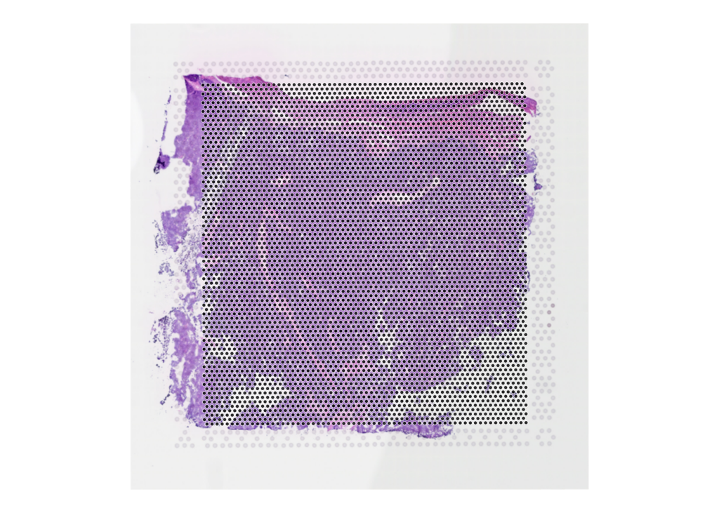

```r
ggspavis::plotVisium(spe)
```

Here, we see the spots overlaid on the slide as well as slide boundaries. You’ll notice that every single spot is shown, including ones that don’t overlap tissue directly. Indeed, all 4992 spots are present in the object right now.

By default, `ggspavis::plotVisium()` shows the spots, but we can hide them and zoom into the tissue on the slide. This is a helpful way to pop up the H&E for side-by-side comparisons with other plots we might make (foreshadowing!).

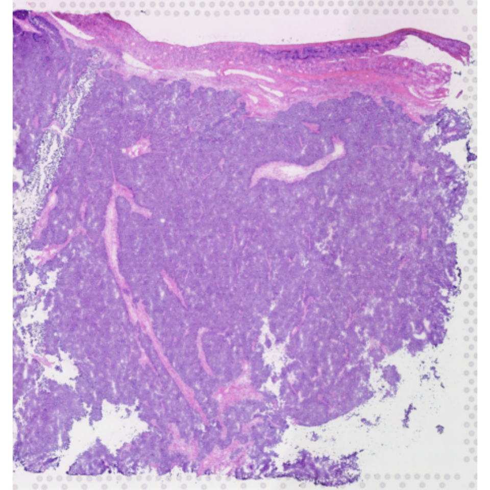

```r
ggspavis::plotVisium(
  spe,
  spots = FALSE, # don't show the spots
  zoom = TRUE # zoom into the slide area
)
```

Any histology experts see patterns in this Wilms tumor you want to point out? We’ll talk more about this slide later in the notebook, but for now, we’ll just note that there seem to be a couple different tissue compartments distinguished by different nuclear densities.

We can also plot only values from the spots themselves with `ggspavis::plotCoords()`.

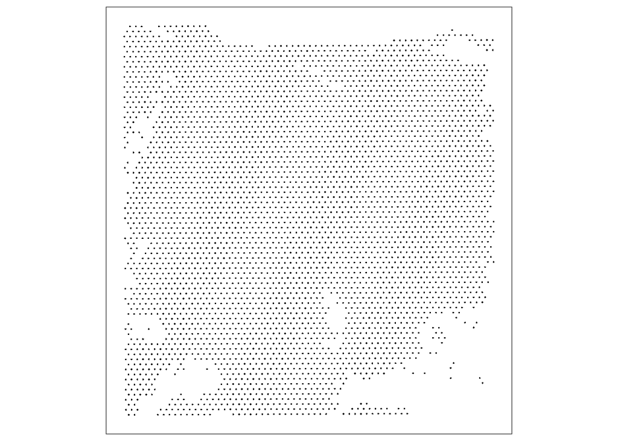

```r
# plot just the spots
ggspavis::plotCoords(spe)
```

## Filtering empty spots

As stated, let’s go ahead and remove those spots entirely. As a rough analogy, this analysis step is reminiscent of filtering empty droplets from single-cell data to retain only droplets with cells, but in this case, we want to retain only spots that overlap tissue.

Again, we need to take this step because we read in the `raw_feature_bc_matrix` output from 10x. Had we read in the `filtered_feature_bc_matrix` instead, the data would already be filtered to only contain spots overlapping tissue. Generally in your own analyses, it’s very safe (and with other related Visium technologies, it’s often recommended) to start by reading in the `filtered_feature_bc_matrix`. Here, we’re taking these steps to ensure a thorough exploration of the SPE object.

Before we filter, it can help to visualize which spots we’ll remove. We’ll plot this on top of the H&E using `ggspavis::plotVisium()` to be able to clearly see the relationship between coordinates and tissue. For this, we’d like to use the `annotate` argument to color by the `in_tissue` column, but `ggspavis` interprets this column as an integer and forces it to use a continuous color scale. So, before plotting, we’ll recast this value to a factor so we can plot it as a discrete variable.

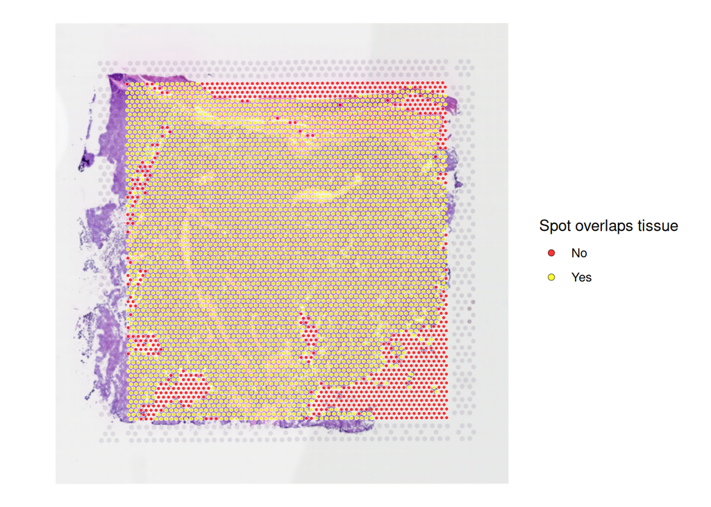

```r
# make a factor version of this column to plot with, specifying "No" and "Yes" plot labels
spe$in_tissue_factor <- factor(
  spe$in_tissue,
  levels = c(0, 1),
  labels = c("No", "Yes")
)

ggspavis::plotVisium(
  spe,
  annotate = "in_tissue_factor",
  # specify a custom palette
  pal = c("Yes" = "yellow", "No" = "red")
) +
  # use guides() to override legend titles in ggspavis
  guides(
    fill = guide_legend(
      title = "Spot overlaps tissue",
      override.aes = list(size = 2)
    )
  )
```

In this plot, we see the following:

- The purple tissue overhang on the left isn’t colored at all; these spots are outside the fiducial alignment frame and have no corresponding spots
- The red points represent those we want to filter out as uninformative

Let’s go ahead and filter:

```r
# keep only spots that are in the tissue and save to filtered_spe
filtered_spe <- spe[, spe$in_tissue == 1]

# print resulting filtered_spe
filtered_spe
```

```
class: SpatialExperiment
dim: 60664 4210
metadata(2): resources spatialList
assays(1): counts
rownames(60664): ENSG00000284662 ENSG00000186827 ... ENSG00000277475
  ENSG00000275405
rowData names(3): ID Symbol Type
colnames(4210): AAACAACGAATAGTTC-1 AAACAAGTATCTCCCA-1 ...
  TTGTTTGTATTACACG-1 TTGTTTGTGTAAATTC-1
colData names(5): in_tissue array_row array_col sample_id
  in_tissue_factor
reducedDimNames(0):
mainExpName: Gene Expression
altExpNames(0):
spatialCoords names(2) : pxl_col_in_fullres pxl_row_in_fullres
imgData names(4): sample_id image_id data scaleFactor
```

We’ve kept 4210 spots of the original 4992, meaning that the vast majority of spots are over tissue. But not all of those spots are necessarily good quality, so we’ll want to do some additional QC filtering next.

## Filtering low-quality spots

When identifying low-quality spots in Visium data, we can use similar QC statistics that we might use for filtering scRNA-seq data, such as:

- Total UMIs, or library size
- Number of unique detected genes
- Percentage of mitochondrial reads, where high values indicate cell damage

However, we’ll learn in the following sections that we interpret and use these statistics somewhat differently from single-cell data.

### Exploring global QC thresholds

First we need to import our list of mitochondrial genes to use as part of these calculations.

```r
# read in a table of mitochondrial genes and extract ids
mito_genes <- readr::read_tsv(mito_file) |>
  # filter to only the genes that are found in our dataset
  dplyr::filter(gene_id %in% rownames(filtered_spe)) |>
  # create a vector from the gene_id column
  dplyr::pull(gene_id)
```

```r
# calculate per-spot statistics
filtered_spe <- scuttle::addPerCellQC(
  filtered_spe,
  subsets = list(mito = mito_genes)
)

# print resulting colData to see QC stats
colData(filtered_spe) |> head()
```

```
DataFrame with 6 rows and 11 columns
                   in_tissue array_row array_col   sample_id in_tissue_factor
                   <integer> <integer> <integer> <character>         <factor>
AAACAACGAATAGTTC-1         1         0        16    sample01              Yes
AAACAAGTATCTCCCA-1         1        50       102    sample01              Yes
AAACACCAATAACTGC-1         1        59        19    sample01              Yes
AAACAGAGCGACTCCT-1         1        14        94    sample01              Yes
AAACAGCTTTCAGAAG-1         1        43         9    sample01              Yes
AAACAGGGTCTATATT-1         1        47        13    sample01              Yes
                         sum  detected subsets_mito_sum subsets_mito_detected
                   <numeric> <integer>        <numeric>             <integer>
AAACAACGAATAGTTC-1     12844      4245              290                    13
AAACAAGTATCTCCCA-1     36976      7053              735                    12
AAACACCAATAACTGC-1     32343      6695              860                    14
AAACAGAGCGACTCCT-1     38482      7404              710                    12
AAACAGCTTTCAGAAG-1     32664      6770              726                    14
AAACAGGGTCTATATT-1     36069      6951              803                    13
                   subsets_mito_percent     total
                              <numeric> <numeric>
AAACAACGAATAGTTC-1              2.25786     12844
AAACAAGTATCTCCCA-1              1.98778     36976
AAACACCAATAACTGC-1              2.65900     32343
AAACAGAGCGACTCCT-1              1.84502     38482
AAACAGCTTTCAGAAG-1              2.22263     32664
AAACAGGGTCTATATT-1              2.22629     36069
```

We’ll first look at the distributions of these statistics (always plot your data!) to see how many spots appear to be low-quality.

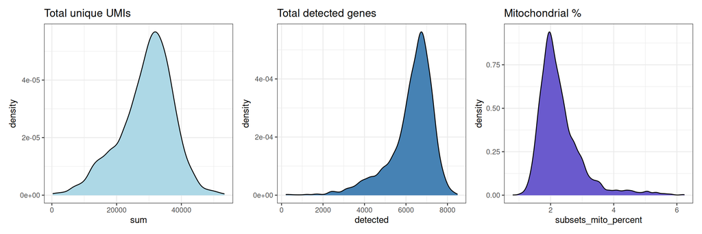

```r
# Extract the colData into a data frame for plotting
coldata_df <- colData(filtered_spe) |>
  as.data.frame() |>
  # relocate barcodes to an actual column instead of rownames
  tibble::rownames_to_column("barcode")

# Define density plots for each statistic
qc_plot_sum <- ggplot(coldata_df) +
  aes(x = sum) +
  geom_density(fill = "lightblue") +
  labs(title = "Total unique UMIs")

qc_plot_detected <- ggplot(coldata_df) +
  aes(x = detected) +
  geom_density(fill = "steelblue") +
  labs(title = "Total detected genes")

qc_plot_mito <- ggplot(coldata_df) +
  aes(x = subsets_mito_percent) +
  geom_density(fill = "slateblue") +
  labs(title = "Mitochondrial %")


# Plot together with patchwork
qc_plot_sum + qc_plot_detected + qc_plot_mito
```

If you’ve worked with single-cell data lately, these distributions might look different from what you might have expected. In single-cell data, these distributions usually have long tails comprising low-quality cells that either have very few total UMIs, very few detected genes, or a very high mitochondrial percentage.

Here, we see three unimodal distributions without much skew, although the `detected` and `subsets_mito_percent` distributions do show some tails potentially indicating low-quality spots. We might be tempted to use these tails to inform global thresholds for filtering, but a closer look suggests that likely wouldn’t help remove low-quality spots. For example, a natural threshold for this `subsets_mito_percent` distribution might be around 4%, but that’s actually quite low mitochondrial percentage that does *not* actually suggest those spots contain damaged cells.

What’s actually going on here, and what should we do about it?

- First, because each sequenced spot is an aggregate of cells, quality issues in individual cells can end up being smoothed out by their neighbors, so we may not easily perceive those signatures in per-spot statistics.
- Second, the technical factors that affect spatial transcriptomic data quality are fundamentally different from the factors that affect single-cell data quality. In single-cell data, differences in cell capture across droplets are a main source of quality issues that lead to cell damage or cells with very few UMIs or genes. Due to fundamental differences in library preparation, this is not a factor in spatial transcriptomic data; instead, problems with tissue preparation (e.g., tissue did not lay flat on the slide or was not permeabilized homogeneously) tend to be a more significant factor driving differences in QC statistics.
- Third, the biological heterogeneity in the tissue means that using global thresholds to filter has substantial potential to *bias* analysis. For example, if a particular tissue compartment is dominated by cell types which naturally have lower expression, we might end up filtering out meaningful regions of the tissue. As such, the QC statistics themselves can be confounded with spatial biology. Filtering using global thresholds assumes that signal from low-quality cells (or spots) should trump signal from biological heterogeneity, but this assumption is not clearly met for spatial data.

To see their full spatial context, we’ll plot those same QC statistics directly on the slide coordinates. We’ll also include the H&E plot here to be able to quickly compare patterns seen in each panel.

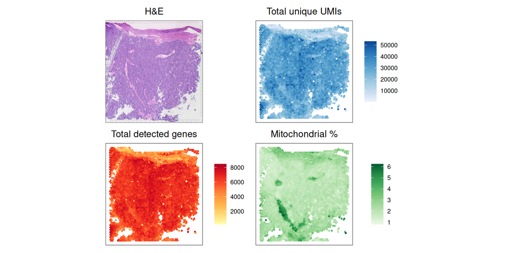

```r
# create the H&E plot
he_plot <- ggspavis::plotVisium(filtered_spe, spots = FALSE, zoom = TRUE) +
  labs(title = "H&E") +
  # add styling to match other panels
  theme(
    plot.title = element_text(
      hjust = 0.5,
      margin = margin(0, 0, 0.1, 0)
    ),
    panel.border = element_rect(color = "black", linewidth = 0.25)
  )

# plots for each QC measure
qc_spots_sum <- ggspavis::plotCoords(
  filtered_spe,
  annotate = "sum",
  point_size = 1
) +
  # use distinct palette
  scale_color_distiller(palette = "Blues", direction = 1) +
  labs(title = "Total unique UMIs")

qc_spots_detected <- ggspavis::plotCoords(
  filtered_spe,
  annotate = "detected",
  point_size = 1
) +
  # use distinct palette
  scale_color_distiller(palette = "YlOrRd", direction = 1) +
  labs(title = "Total detected genes")

qc_spots_mito <- ggspavis::plotCoords(
  filtered_spe,
  annotate = "subsets_mito_percent",
  point_size = 1
) +
  # use distinct palette
  scale_color_distiller(palette = "Greens", direction = 1) +
  labs(title = "Mitochondrial %")

# wrap plots with patchwork into 2x2 grid
patchwork::wrap_plots(
  he_plot,
  qc_spots_sum,
  qc_spots_detected,
  qc_spots_mito,
  nrow = 2
)
```

Compare the H&E image to these statistics: do you notice any patterns that suggest the statistics are confounded by spatial biology?

This shows us that if we were to filter out, for example, spots with overall lower total UMIs or detected genes, we would end up primarily (if not only) removing spots in particular tissue types, which is probably not what we want. As such, using global thresholds is not going to be suitable for spatial data, so we’ll need a different approach to filter spots. (It’s worth noting that this is not strictly a spatial transcriptomics issue; it’s very possible for differences among cell types to confound QC statistics in single-cell data too. Always plot your data to make sure your filters make sense for your data!)

### Filtering with local QC thresholds

Rather than finding outliers based on overall QC statistics derived across biologically distinct tissue regions, we can instead look for *local* outliers to filter. These are spots whose properties differ from their local neighborhood of nearby spots. For this, we’ll use the [`SpotSweeper`](https://www.bioconductor.org/packages/3.22/bioc/vignettes/SpotSweeper/inst/doc/getting_started.html) package, which offers several useful tools for quality control of spot-based data.

We’ll specifically use their local outlier detection function `SpotSweeper::localOutliers()`. This function uses a k-nearest neighbors approach to define the neighborhood for each spot and then calculates *local* means and variances of standard QC metrics to identify outlying spots within their local tissue context. This approach reduces the chance that we’ll bias filtering by tissue biology because we generally expect nearby spots in the same tissue region to be more biologically similar to each other.

It’s also worth noting that `SpotSweeper` also has the ability to detect so-called “hangnails,” which are regional technical artifacts resulting from issues with tissue preparation. Their hangnail detection uses variance in mitochondrial percentages, and since our mitochondrial percentages are very low with minimal variance, hangnail detection won’t be relevant for us here.

`SpotSweeper::localOutliers()` returns an SPE object with added `colData` columns we can use to find all the local outliers and takes these arguments:

Let’s start off by looking for outliers in the `sum` column, which represents library size (total UMIs).

```r
filtered_spe <- SpotSweeper::localOutliers(
  filtered_spe,
  metric = "sum",
  direction = "lower",
  n_neighbors = 36,
  log = TRUE,
  cutoff = 3
)
```

What’s in our `colData` now?

```r
colData(filtered_spe)
```

```
DataFrame with 4210 rows and 14 columns
                   in_tissue array_row array_col   sample_id in_tissue_factor
                   <integer> <integer> <integer> <character>         <factor>
AAACAACGAATAGTTC-1         1         0        16    sample01              Yes
AAACAAGTATCTCCCA-1         1        50       102    sample01              Yes
AAACACCAATAACTGC-1         1        59        19    sample01              Yes
AAACAGAGCGACTCCT-1         1        14        94    sample01              Yes
AAACAGCTTTCAGAAG-1         1        43         9    sample01              Yes
...                      ...       ...       ...         ...              ...
                         sum  detected subsets_mito_sum subsets_mito_detected
                   <numeric> <integer>        <numeric>             <integer>
AAACAACGAATAGTTC-1     12844      4245              290                    13
AAACAAGTATCTCCCA-1     36976      7053              735                    12
AAACACCAATAACTGC-1     32343      6695              860                    14
AAACAGAGCGACTCCT-1     38482      7404              710                    12
AAACAGCTTTCAGAAG-1     32664      6770              726                    14
...                      ...       ...              ...                   ...
                   subsets_mito_percent     total   sum_log sum_outliers
                              <numeric> <numeric> <numeric>    <logical>
AAACAACGAATAGTTC-1              2.25786     12844   9.46071        FALSE
AAACAAGTATCTCCCA-1              1.98778     36976  10.51805        FALSE
AAACACCAATAACTGC-1              2.65900     32343  10.38418        FALSE
AAACAGAGCGACTCCT-1              1.84502     38482  10.55797        FALSE
AAACAGCTTTCAGAAG-1              2.22263     32664  10.39406        FALSE
...                                 ...       ...       ...          ...
                       sum_z
                   <numeric>
AAACAACGAATAGTTC-1 0.0638387
AAACAAGTATCTCCCA-1 0.4367221
AAACACCAATAACTGC-1 0.2530256
AAACAGAGCGACTCCT-1 0.5013254
AAACAGCTTTCAGAAG-1 0.5853461
...                      ...
 [ reached 'max' / getOption("max.print") -- omitted 5 rows ]
```

`SpotSweeper` gave us a couple new columns:

- `sum_log`: The `log1p()` (i.e., `log(x+1)`) of the `sum` column
- `sum_outliers`: Whether or not the spot is a *local* outlier in its local neighborhood. Generally we’ll want to filter out rows where this is `TRUE`
- `sum_z`: The *local* z-score for `sum_log` used for identifying outliers relative to the specified cutoff (here, -3)
  - A value of 0 means the spot is, on average, the same as its neighbors
  - A high positive value means the spot has a much higher `sum` than its local neighborhood
  - A low negative value means the spot has a much lower `sum` than its local neighborhood. These are the spots we’ll want to filter out

Let’s look at some of these values directly by plotting `sum_z` against `sum_log`.

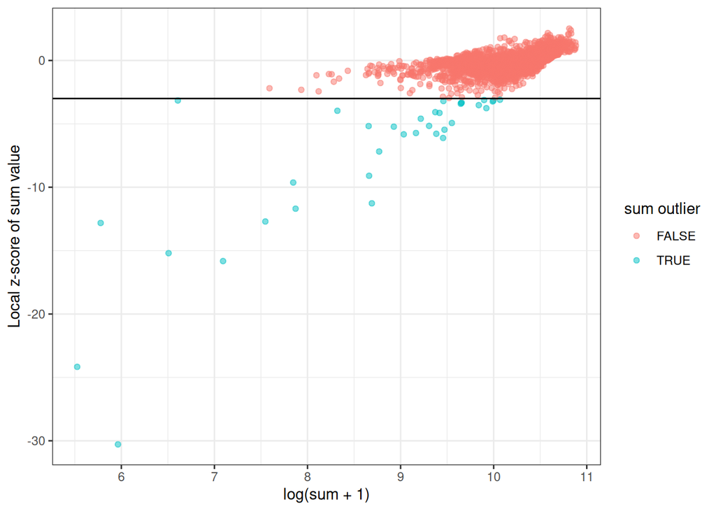

```r
# extract data frame for plotting
filtered_spe_coldata <- colData(filtered_spe) |>
  as.data.frame()

# Plot sum_z across sum_log
ggplot(filtered_spe_coldata) +
  aes(
    x = sum_log,
    y = sum_z,
    color = sum_outliers
  ) +
  geom_point(alpha = 0.5) +
  # add a line for the cutoff value
  geom_hline(yintercept = -3) +
  # and some labels
  labs(
    x = "log(sum + 1)",
    y = "Local z-score of sum value",
    color = "sum outlier"
  )
```

We see here that most spots are not outliers for the `sum` metric. Most of the spots classified as outliers are fairly close to the -3 z-score cutoff, but several are more extreme outliers.

We also learn from this plot how performing filtering using global vs. local outliers would play out. Imagine if we had performed global filtering with a threshold of 500, which has a log of 6.21. At a cutoff of `sum_log = 6.21`, we would only have removed three spots. By using local outlier detection, we have identified several more spots to remove whose `sum` is much lower than their immediately surrounding spots, suggesting potential quality issues. On the whole though, this dataset is fairly good quality so there aren’t many of these low-quality spots.

We can also plot these results on the coordinates themselves, using the H&E image as a guide for interpretation. For this, we’ll use the function `SpotSweeper::plotQCmetrics()` which lets you both color by a statistic and highlight outlier points, so we’ll plot both `sum_log` and `sum_z` with outliers highlighted.

Tip! When using this function, the point color is a “fill” `ggplot2` aesthetic, and the point outline is a “color” `ggplot2` aesthetic. We can use this knowledge to help us to customize the plot colors.

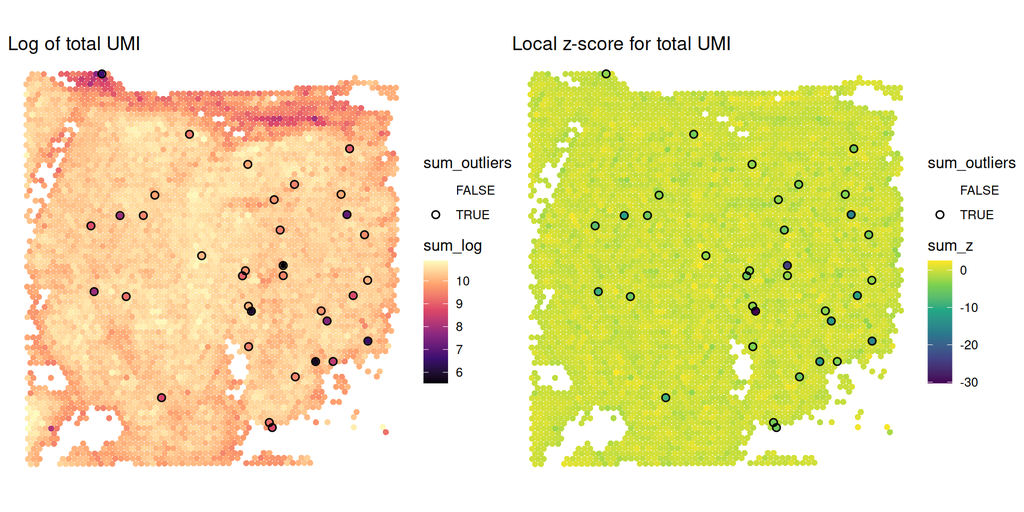

```r
sum_log_plot <- SpotSweeper::plotQCmetrics(
  filtered_spe,
  metric = "sum_log", # how to *fill* spots
  outliers = "sum_outliers", # which spots to *color* with an outline
  stroke = 0.75 # size of outline
) +
  # customize the palette for filling spots
  scale_fill_viridis_c(option = "magma") +
  # customize the outlier outline
  scale_color_manual(values = c(`TRUE` = "black", `FALSE` = "transparent")) +
  labs(title = "Log of total UMI")


sum_z_plot <- SpotSweeper::plotQCmetrics(
  filtered_spe,
  metric = "sum_z", # how to *fill* spots
  outliers = "sum_outliers", # which spots to *color* with an outline
  stroke = 0.75 # size of outline
) +
  scale_fill_viridis_c() +
  scale_color_manual(values = c(`TRUE` = "black", `FALSE` = "transparent")) +
  labs(title = "Local z-score for total UMI")

sum_log_plot + sum_z_plot
```

These plots show us how spots are distributed across the tissue. Are there spots you would expect to be flagged for filtering based on the `sum_log` plot?

We can take the same approach for local outlier detection for the `detected` and `subsets_mito_percent` columns, and we’ll proceed with the default cutoff of 3 with the default neighborhood size of 36. We’ll do this one at a time below.

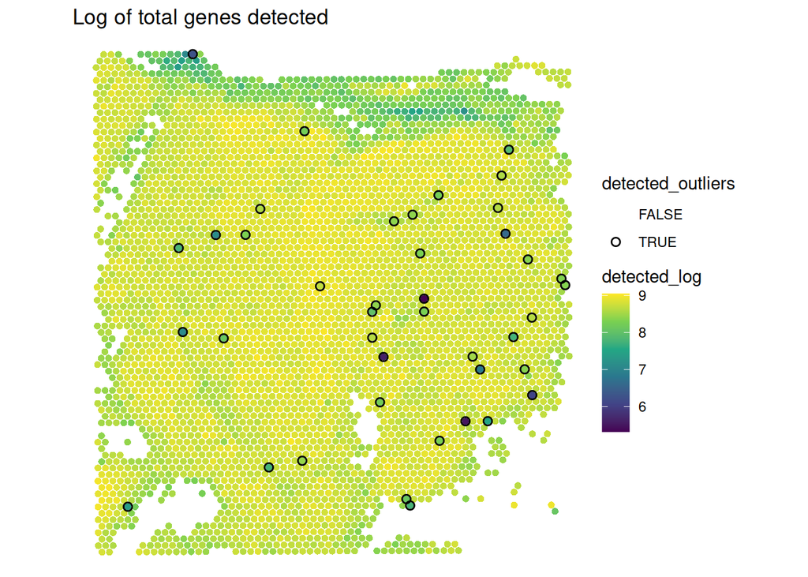

```r
# Calculate local outliers for the `detected` metric
filtered_spe <- SpotSweeper::localOutliers(
  filtered_spe,
  metric = "detected",
  direction = "lower"
)

# Plot the slide showing outliers
SpotSweeper::plotQCmetrics(
  filtered_spe,
  metric = "detected_log",
  outliers = "detected_outliers",
  stroke = 0.75
) +
  scale_color_manual(values = c(`TRUE` = "black", `FALSE` = "transparent")) +
  scale_fill_viridis_c() +
  labs(title = "Log of total genes detected")
```

As with local `sum` outliers, we see that the `detected` outliers are spread out across the whole tissue and not concentrated in specific tissue regions.

Next, when calculating outliers for `subsets_mito_percent`, we’ll need to specify `log = FALSE` and `direction = higher` since this is a bounded metric where we want to remove spots with higher than average values.

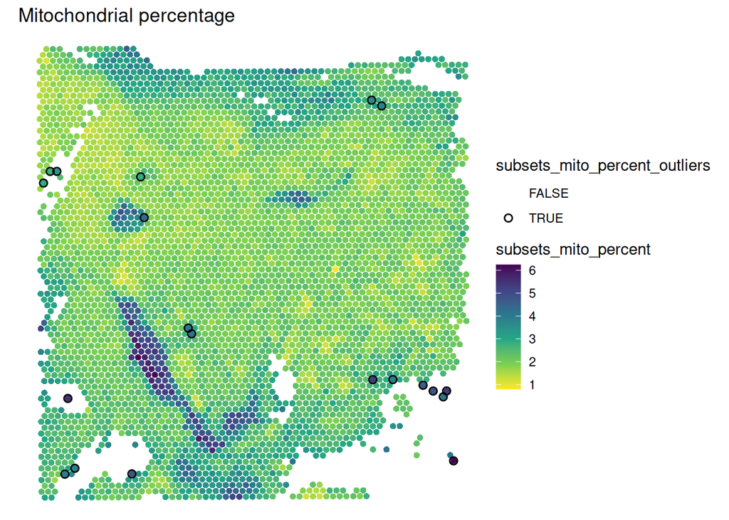

```r
# Calculate local outliers for the `subsets_mito_percent` metric
filtered_spe <- SpotSweeper::localOutliers(
  filtered_spe,
  metric = "subsets_mito_percent",
  direction = "higher", # we want to remove HIGHER values
  log = FALSE, # don't log
  cutoff = 3
)

# Plot the slide showing outliers
SpotSweeper::plotQCmetrics(
  filtered_spe,
  metric = "subsets_mito_percent",
  outliers = "subsets_mito_percent_outliers",
  stroke = 0.75
) +
  # switch palette direction to make outliers are darker colors, matching other plots
  scale_fill_viridis_c(direction = -1) +
  scale_color_manual(values = c(`TRUE` = "black", `FALSE` = "transparent")) +
  labs(title = "Mitochondrial percentage")
```

Importantly, we see here that spots to remove are *not* concentrated in tissue regions with higher mitochondrial percentages, but are instead spread across the tissue. This shows us again that our local outlier detection approach allows us to avoid the confounding effects of spatial heterogeneity. It’s also worth noting that none of these spots would have been removed with a typical global threshold used for single-cell data (e.g., 10-25%).

Now that we’ve calculated all this, we can pool our outliers together: how many outliers are there for each statistic?

```r
# Prepare data frame to count outliers
outliers_df <- colData(filtered_spe) |>
  as.data.frame() |>
  dplyr::select(ends_with("_outliers"))

# Count total outliers for each metric: The total TRUE values in the `sum_` columns
outliers_df |>
  dplyr::summarize(
    sum_outlier_count = sum(sum_outliers),
    detected_outlier_count = sum(detected_outliers),
    mito_outlier_count = sum(subsets_mito_percent_outliers)
  )
```

| sum_outlier_count | detected_outlier_count | mito_outlier_count |
| --- | --- | --- |
| 35 | 41 | 20 |

Let’s visualize how these outliers relate to one another with a proportional Venn Diagram, using the `eulerr` package to help us:

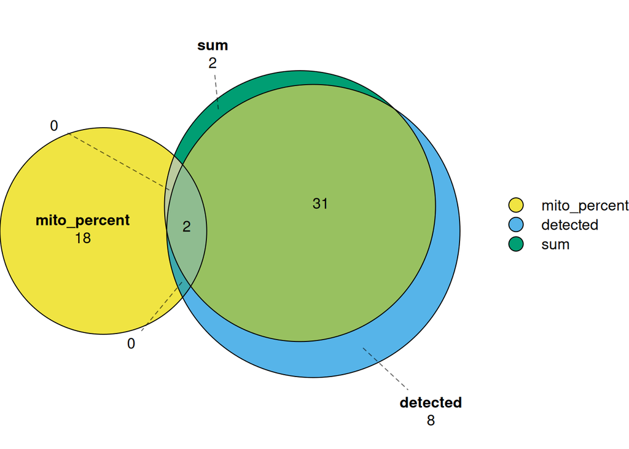

```r
eulerr_data <- outliers_df |>
  # reorder & rename columns columns for display
  dplyr::select(
    mito_percent = subsets_mito_percent_outliers,
    detected = detected_outliers,
    sum = sum_outliers
  ) |>
  # venn diagram calculations
  eulerr::euler()

plot(
  eulerr_data,
  quantities = TRUE,
  legend = TRUE,
  labels = TRUE,
  fills = c("#F0E442", "#56B4E9", "#009E73")
)
```

We see substantial overlap between `sum` and `detected` outliers, but the `subsets_mito_percent` outliers appear to be mostly distinct.

Next, we’ll build a filter representing the union of all types of outliers and use it to filter the SPE object.

```r
# combine all outliers into "local_outliers" column to filter on
filtered_spe$local_outliers <- filtered_spe$sum_outliers |
  filtered_spe$detected_outliers |
  filtered_spe$subsets_mito_percent_outliers

# how many total outliers?
sum(filtered_spe$local_outliers)
```

```
[1] 61
```

```r
# keep only spots where `local_outliers` is FALSE
filtered_spe <- filtered_spe[, !filtered_spe$local_outliers]

# print resulting SPE
filtered_spe
```

```
class: SpatialExperiment
dim: 60664 4149
metadata(2): resources spatialList
assays(1): counts
rownames(60664): ENSG00000284662 ENSG00000186827 ... ENSG00000277475
  ENSG00000275405
rowData names(4): ID Symbol Type subsets_mito
colnames(4149): AAACAACGAATAGTTC-1 AAACAAGTATCTCCCA-1 ...
  TTGTTTGTATTACACG-1 TTGTTTGTGTAAATTC-1
colData names(20): in_tissue array_row ... subsets_mito_percent_z
  local_outliers
reducedDimNames(0):
mainExpName: Gene Expression
altExpNames(0):
spatialCoords names(2) : pxl_col_in_fullres pxl_row_in_fullres
imgData names(4): sample_id image_id data scaleFactor
```

After removing these additional 61 spots, we are left with 4149 spots that both overlap tissue and don’t have obvious quality issues.

## Normalization

Our next step is to normalize counts. In single-cell data, we often use a [deconvolution-based approach](https://bioconductor.org/books/3.22/OSCA.basic/normalization.html#normalization-by-deconvolution) for normalization. This entails performing a quick clustering across cells, calculating a scaling factor for each cluster, and then normalizing using each cell’s associated scaling factor.

However, this approach isn’t quite suitable for our Visium spatial transcriptomics data since each spot is a heterogeneous composition of 1-10 cells. We’ll therefore use a so-called [“library-size normalization approach”](https://bioconductor.org/books/3.22/OSTA/pages/seq-intermediate-processing.html#library-size-normalization) which treats each spot fully independently.

That said, it’s important to note that this normalization approach might not be ideal either, as there’s some evidence that library size itself [can be confounded with spatial structure](https://link.springer.com/article/10.1186/s13059-024-03241-7). [Some methods have been proposed](https://bioconductor.org/books/3.22/OSTA/pages/seq-intermediate-processing.html#spatially-aware-normalization) to circumvent this by taking spatial information into account. The takeaway: Method development in spatial transcriptomics is ongoing and a scientific consensus is still forming, so keep your eyes peeled for fresh developments in this space.

Either way, we’ll now proceed to normalize using `scuttle::computeLibraryFactors()` to first calculate our spot-specific size factors.

```r
# calculate per-spot size factors
filtered_spe <- scuttle::computeLibraryFactors(filtered_spe)

# perform normalization
norm_spe <- scuttle::logNormCounts(filtered_spe)

# view normalized SPE
norm_spe
```

```
class: SpatialExperiment
dim: 60664 4149
metadata(2): resources spatialList
assays(2): counts logcounts
rownames(60664): ENSG00000284662 ENSG00000186827 ... ENSG00000277475
  ENSG00000275405
rowData names(4): ID Symbol Type subsets_mito
colnames(4149): AAACAACGAATAGTTC-1 AAACAAGTATCTCCCA-1 ...
  TTGTTTGTATTACACG-1 TTGTTTGTGTAAATTC-1
colData names(21): in_tissue array_row ... local_outliers sizeFactor
reducedDimNames(0):
mainExpName: Gene Expression
altExpNames(0):
spatialCoords names(2) : pxl_col_in_fullres pxl_row_in_fullres
imgData names(4): sample_id image_id data scaleFactor
```

We now have a new `logcounts` slot with normalized count data:

```r
# show top corner of logcounts assay
logcounts(norm_spe)[1:6, 1:6]
```

```
6 x 6 sparse Matrix of class "dgCMatrix"
                AAACAACGAATAGTTC-1 AAACAAGTATCTCCCA-1 AAACACCAATAACTGC-1
ENSG00000284662           .                         .                  .
ENSG00000186827           .                         .                  .
ENSG00000186891           .                         .                  .
ENSG00000160072           2.482957                  .                  .
ENSG00000041988           .                         .                  .
ENSG00000260179           .                         .                  .
                AAACAGAGCGACTCCT-1 AAACAGCTTTCAGAAG-1 AAACAGGGTCTATATT-1
ENSG00000284662          .                          .          .
ENSG00000186827          .                          .          .
ENSG00000186891          .                          .          .
ENSG00000160072          1.3403506                  .          0.8618074
ENSG00000041988          0.8205378                  .          1.3975988
ENSG00000260179          .                          .          .
```

## Exploring gene expression

Finally, the moment we’ve all been waiting for: Let’s make some pretty plots! Spatial data, by definition, already has a handy coordinate system, which gives us a meaningful layout for visualizing spatial data. Although each spot isn’t a cell, we can still color spots by expression of genes of interest to get a general sense of what cell types or tissue regions might be in our sample.

To orient us once again, here is the H&E image:

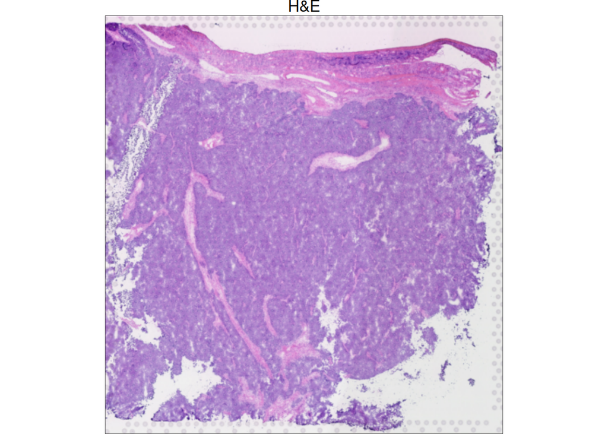

```r
he_plot
```

We’ll take a bit of time to interpret this image (with the caveat that we are not histology experts, but we’ll do our best). Generally speaking, Wilms Tumors are composed of a several histologic compartments: blastemal, stromal (with mesenchymal biology), and sometimes epithelial components. The H&E shows some evidence for the first two compartments at least:

- Bluer regions indicating ECM-poor areas with high cellular density likely represent a blastemal compartment
- Paler pink regions likely represent a stromal compartment that may have an endothelial presence

We’ll now use some exploratory visualization to see if we can have evidence for these compartments. For this, we’ll plot expression using `ggpsavis::plotCoords()` for two genes:

- `WT1`: A transcription factor that regulates kidney development. We expect this gene to be highly expressed in Wilms Tumor blastemal compartments
- `COL1A1`: A collagen protein that we expect to be highly expressed in stromal/mesenchymal compartments

We’ll need to provide the gene’s corresponding row name, which is its Ensembl gene id, to `ggpsavis::plotCoords()` so let’s go ahead and find those first.

Recall, the `rowData` slot helpfully maps between gene symbols and Ensembl ids:

```r
rowData(spe) |> head()
```

```
DataFrame with 6 rows and 3 columns
                             ID          Symbol            Type
                    <character>     <character>     <character>
ENSG00000284662 ENSG00000284662          OR4F16 Gene Expression
ENSG00000186827 ENSG00000186827         TNFRSF4 Gene Expression
ENSG00000186891 ENSG00000186891        TNFRSF18 Gene Expression
ENSG00000160072 ENSG00000160072          ATAD3B Gene Expression
ENSG00000041988 ENSG00000041988           THAP3 Gene Expression
ENSG00000260179 ENSG00000260179 ENSG00000260179 Gene Expression
```

In the next chunk, we’ll filter the `rowData` to our genes of interest so we can grab Ensembl ids for plotting.

```r
# define gene symbols
gene_symbols <- c("WT1", "COL1A1")

# filter rowData to genes of interest
rowData(spe) |>
  as.data.frame() |>
  dplyr::filter(Symbol %in% gene_symbols)
```

|  | ID | Symbol | Type |
| --- | --- | --- | --- |
| ENSG00000184937 | ENSG00000184937 | WT1 | Gene Expression |
| ENSG00000108821 | ENSG00000108821 | COL1A1 | Gene Expression |

First up, we’ll plot the expression of `WT1` using `ggpspavis::plotCoords()`. We’ll also show the H&E plot next to it to help us interpret it.

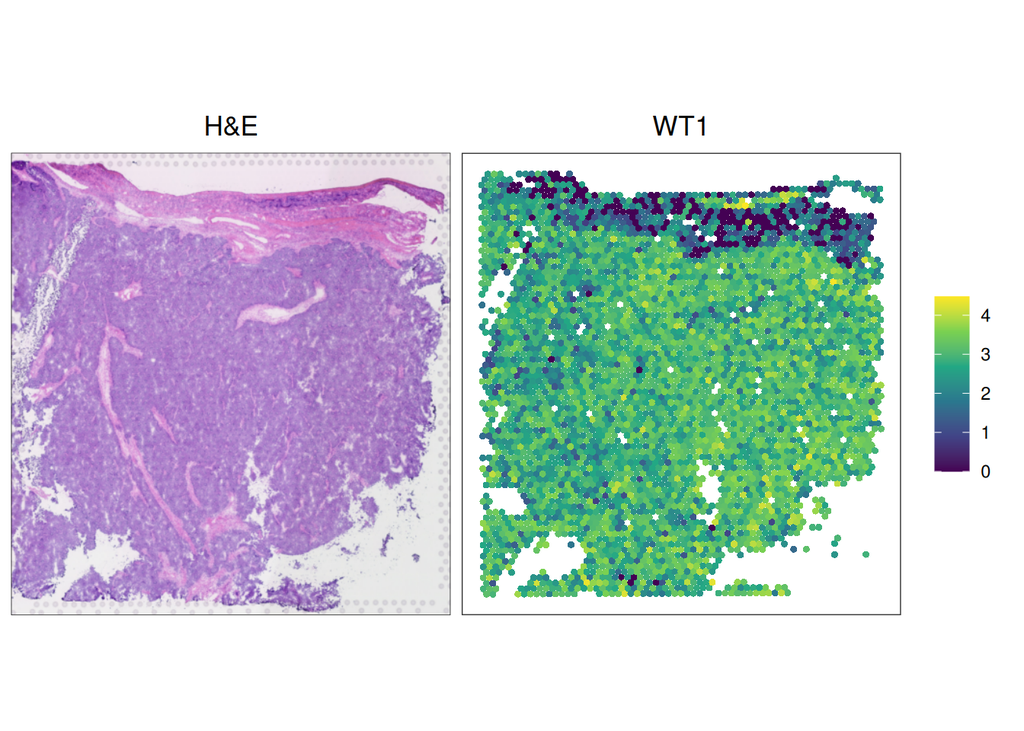

```r
# save plot of WT1 to a variable
wt1_plot <- ggspavis::plotCoords(
  norm_spe,
  annotate = "ENSG00000184937", # name of variable to color by. here, an Ensembl id
  assay = "logcounts", # counts are plotted by default, so we need to override this
  point_size = 1.25
) +
  scale_color_viridis_c() + # custom color scale
  labs(title = "WT1")

# plot h&e with WT1 plot
he_plot + wt1_plot
```

What patterns do you see here? Do you think there is potentially spatial structure to `WT1` expression? You might also notice a band of spots with high `WT1` expression embedded in a band of spots with lower `WT1` expression along the top of the coordinates plot; can you see how this related back to the H&E?

Let’s compare this to `COL1A1` expression, whose Ensembl id we determined is `ENSG00000108821`. Again, we’ll plot this alongside the H&E.

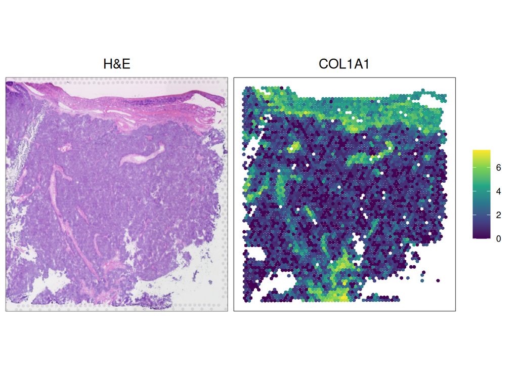

```r
# create COL1A1 plot and save to variable
col1a1_plot <- ggspavis::plotCoords(
  norm_spe,
  annotate = "ENSG00000108821",
  assay = "logcounts",
  point_size = 1.25
) +
  scale_color_viridis_c() +
  labs(title = "COL1A1")

# plot H&E with COL1A1 plot
he_plot + col1a1_plot
```

What differences do you see in this plot of `COL1A1` gene expression compared to `WT1`? Do they appear to be expressed in different tissue regions? Did you expect this based on the H&E?

Based on these (very few, very cursory, and highly exploratory!) plots, do you think there is evidence for blastemal and stromal compartments in this sample?

## Export

Finally, we’ll export the SPE object to the RDS file `output_spe_file` we defined at the top of the notebook.

Very importantly, the version of `VisiumIO` that we used to read in the SPE object earlier actually does not store the images themselves within the SPE object. Instead, it stores the *full path* to the image files to reload them if the exported SPE is read back into R. This works fine if the object is read back into R on exactly the same computer and files are in exactly the same places, but when this is not the case, the images will not properly be loaded when reading the object into R.

The `VisiumIO` version included in the (forthcoming) Bioconductor 3.24 release has addressed this and allows you to fully load images rather than just their full paths when reading in Space Ranger output to create an SPE object. But for now, this is a limitation to be aware of.

```r
# export SPE with compression
readr::write_rds(norm_spe, output_spe_file, compress = "gz")
```

## Session info

To conclude, we’ll run the `sessionInfo()` command to print out exactly what system setting and R package versions were used to run this code.

[session information not shown]